# Project: Investigate a Dataset (IMDB Movie Dataset!)

- Introduction
- Data Wrangling
- Exploratory Data Analysis
- Conclusions

## Introduction

> The IMDB Movie Data is a dataset that contains about ~10,000 data points which was cleaned from the [kaggle](https://www.kaggle.com/datasets/tmdb/tmdb-movie-metadata)

> **NB**: In the dataset, the final two columns ending with `_adj` show the budget and revenue of the associated movie in terms of 2010 dollars, accounting for inflation over time.

> With data on the overview, cast, directors, budget, and revenues of several thousand films, the dataset delves into chances to predict which films will be highly rated, whether or not they are a commercial success.

On a close look at the data (features, origin, and purpose), we can ask the following questions about the data:

- Which genres are most popular from year to year?
- What features are associated with movies that have high revenue?
- Are movies with high revenue synonymous with high votes?
- Which director directed the most popular movie each year?
- Which year has the highest revenue?
- Which director has directed the most movies?

```python
# Use this cell to set up import statements for all of the packages that you
#   plan to use.
import warnings
import itertools
import numpy as np
import pandas as pd
import seaborn as sns
import matplotlib.pyplot as plt

from matplotlib import style
from tqdm.notebook import tqdm
from sklearn import preprocessing
from IPython.display import display

style.use("ggplot")
warnings.filterwarnings("ignore")


# Remember to include a 'magic word' so that your visualizations are plotted
#   inline with the notebook. See this page for more:
#   http://ipython.readthedocs.io/en/stable/interactive/magics.html
%matplotlib inline
```

## Data Wrangling

> In this section of the report, we are going to load in the data, check for cleanliness, and then trim and clean our dataset for analysis

### General Properties

```python
# Load your data and print out a few lines. Perform operations to inspect data
#   types and look for instances of missing or possibly errant data.
df = pd.read_csv("tmdb-movies.csv")
```

```python
# Taking a first look on the data
df.head(3)
```

|  | id | imdb_id | popularity | budget | revenue | original_title | cast | homepage | director | tagline | ... | overview | runtime | genres | production_companies | release_date | vote_count | vote_average | release_year | budget_adj | revenue_adj |
| --- | --- | --- | --- | --- | --- | --- | --- | --- | --- | --- | --- | --- | --- | --- | --- | --- | --- | --- | --- | --- | --- |
| 0 | 135397 | tt0369610 | 32.985763 | 150000000 | 1513528810 | Jurassic World | Chris Pratt\|Bryce Dallas Howard\|Irrfan Khan\|Vi... | http://www.jurassicworld.com/ | Colin Trevorrow | The park is open. | ... | Twenty-two years after the events of Jurassic ... | 124 | Action\|Adventure\|Science Fiction\|Thriller | Universal Studios\|Amblin Entertainment\|Legenda... | 6/9/15 | 5562 | 6.5 | 2015 | 1.379999e+08 | 1.392446e+09 |
| 1 | 76341 | tt1392190 | 28.419936 | 150000000 | 378436354 | Mad Max: Fury Road | Tom Hardy\|Charlize Theron\|Hugh Keays-Byrne\|Nic... | http://www.madmaxmovie.com/ | George Miller | What a Lovely Day. | ... | An apocalyptic story set in the furthest reach... | 120 | Action\|Adventure\|Science Fiction\|Thriller | Village Roadshow Pictures\|Kennedy Miller Produ... | 5/13/15 | 6185 | 7.1 | 2015 | 1.379999e+08 | 3.481613e+08 |
| 2 | 262500 | tt2908446 | 13.112507 | 110000000 | 295238201 | Insurgent | Shailene Woodley\|Theo James\|Kate Winslet\|Ansel... | http://www.thedivergentseries.movie/#insurgent | Robert Schwentke | One Choice Can Destroy You | ... | Beatrice Prior must confront her inner demons ... | 119 | Adventure\|Science Fiction\|Thriller | Summit Entertainment\|Mandeville Films\|Red Wago... | 3/18/15 | 2480 | 6.3 | 2015 | 1.012000e+08 | 2.716190e+08 |

3 rows × 21 columns

```python
df.info()
```

```
<class 'pandas.core.frame.DataFrame'>
RangeIndex: 10866 entries, 0 to 10865
Data columns (total 21 columns):
 #   Column                Non-Null Count  Dtype
---  ------                --------------  -----
 0   id                    10866 non-null  int64
 1   imdb_id               10856 non-null  object
 2   popularity            10866 non-null  float64
 3   budget                10866 non-null  int64
 4   revenue               10866 non-null  int64
 5   original_title        10866 non-null  object
 6   cast                  10790 non-null  object
 7   homepage              2936 non-null   object
 8   director              10822 non-null  object
 9   tagline               8042 non-null   object
 10  keywords              9373 non-null   object
 11  overview              10862 non-null  object
 12  runtime               10866 non-null  int64
 13  genres                10843 non-null  object
 14  production_companies  9836 non-null   object
 15  release_date          10866 non-null  object
 16  vote_count            10866 non-null  int64
 17  vote_average          10866 non-null  float64
 18  release_year          10866 non-null  int64
 19  budget_adj            10866 non-null  float64
 20  revenue_adj           10866 non-null  float64
dtypes: float64(4), int64(6), object(11)
memory usage: 1.7+ MB
```

```python
df.describe()
```

|  | id | popularity | budget | revenue | runtime | vote_count | vote_average | release_year | budget_adj | revenue_adj |
| --- | --- | --- | --- | --- | --- | --- | --- | --- | --- | --- |
| count | 10866.000000 | 10866.000000 | 1.086600e+04 | 1.086600e+04 | 10866.000000 | 10866.000000 | 10866.000000 | 10866.000000 | 1.086600e+04 | 1.086600e+04 |
| mean | 66064.177434 | 0.646441 | 1.462570e+07 | 3.982332e+07 | 102.070863 | 217.389748 | 5.974922 | 2001.322658 | 1.755104e+07 | 5.136436e+07 |
| std | 92130.136561 | 1.000185 | 3.091321e+07 | 1.170035e+08 | 31.381405 | 575.619058 | 0.935142 | 12.812941 | 3.430616e+07 | 1.446325e+08 |
| min | 5.000000 | 0.000065 | 0.000000e+00 | 0.000000e+00 | 0.000000 | 10.000000 | 1.500000 | 1960.000000 | 0.000000e+00 | 0.000000e+00 |
| 25% | 10596.250000 | 0.207583 | 0.000000e+00 | 0.000000e+00 | 90.000000 | 17.000000 | 5.400000 | 1995.000000 | 0.000000e+00 | 0.000000e+00 |
| 50% | 20669.000000 | 0.383856 | 0.000000e+00 | 0.000000e+00 | 99.000000 | 38.000000 | 6.000000 | 2006.000000 | 0.000000e+00 | 0.000000e+00 |
| 75% | 75610.000000 | 0.713817 | 1.500000e+07 | 2.400000e+07 | 111.000000 | 145.750000 | 6.600000 | 2011.000000 | 2.085325e+07 | 3.369710e+07 |
| max | 417859.000000 | 32.985763 | 4.250000e+08 | 2.781506e+09 | 900.000000 | 9767.000000 | 9.200000 | 2015.000000 | 4.250000e+08 | 2.827124e+09 |

> Let's create some plots to visualize the distribution of some of the features

### Histogram plots of various features

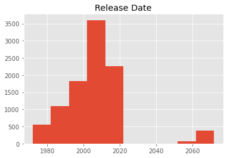

```python
df["release_date"].hist();
plt.title("Release Date");
```

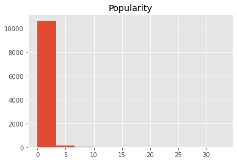

```python
df["popularity"].hist();
plt.title("Popularity");
```

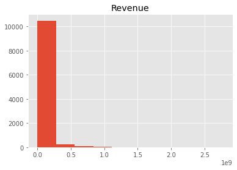

```python
df["revenue"].hist();
plt.title("Revenue");
```

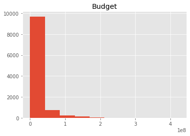

```python
df["budget"].hist();
plt.title("Budget");
```

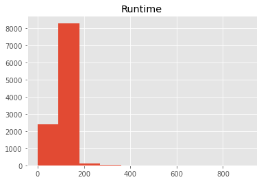

```python
df["runtime"].hist();
plt.title("Runtime");
```

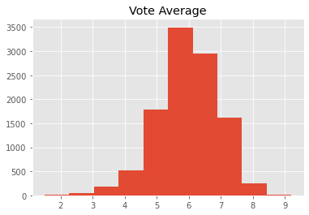

```python
df["vote_average"].hist();
plt.title("Vote Average");
```

### Boxplot of various features

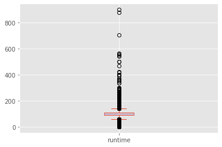

```python
df["runtime"].plot(kind="box");
```

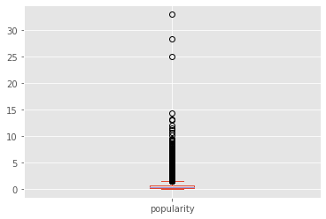

```python
df["popularity"].plot(kind="box");
```

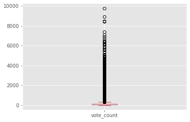

```python
df["vote_count"].plot(kind="box");
```

### Countplots of some categorical features

#### Visualizing the first 30 most common genres

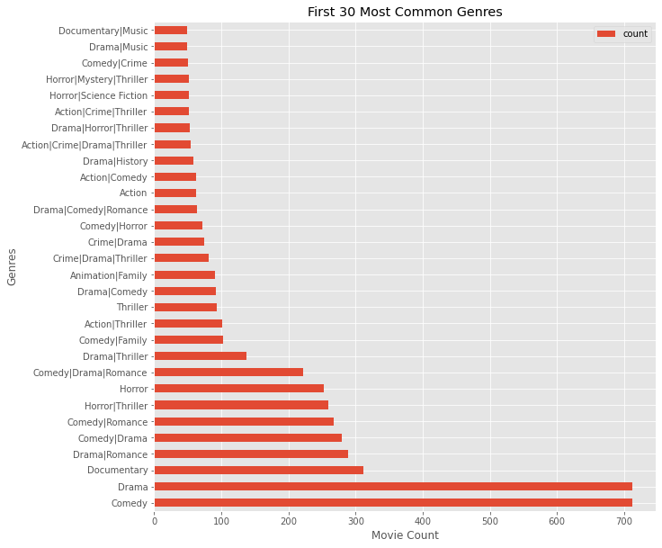

```python
genres_group = df.groupby("genres", as_index=False)["genres"].value_counts()\
                                    .sort_values(["count"], ascending=False)[:30]

genres_group.set_index("genres").plot(kind="barh", figsize=(10,10));
plt.title("First 30 Most Common Genres");
plt.xlabel("Movie Count");
plt.ylabel("Genres");
```

#### Visualizing the first 40 directors with most movies

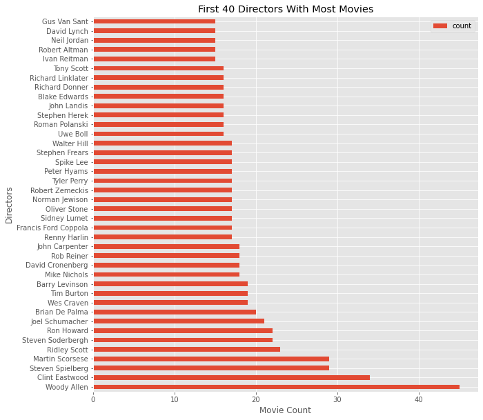

```python
directors_group = df.groupby("director", as_index=False)["director"].value_counts()\
                                    .sort_values(["count"], ascending=False)[:40]

directors_group.set_index("director").plot(kind="barh", figsize=(10,10));
plt.title("First 40 Directors With Most Movies");
plt.xlabel("Movie Count");
plt.ylabel("Directors");
```

### Data Cleaning

```python
# Check columns with null values and the count of the null values
df.isnull().sum()
```

```
id                         0
imdb_id                   10
popularity                 0
budget                     0
revenue                    0
original_title             0
cast                      76
homepage                7930
director                  44
tagline                 2824
keywords                1493
overview                   4
runtime                    0
genres                    23
production_companies    1030
release_date               0
vote_count                 0
vote_average               0
release_year               0
budget_adj                 0
revenue_adj                0
dtype: int64
```

> By looking the output of the cell above we can see that the columns: `imdb_id`, `cast`, `homepage`, `director`, `tagline`, `keywords`, `overview`, and `production_companies` all have null values. However, the column: `homepage` has too many null values so we are going to drop it along with the`tagline` which has almost $25\%$ of its values null.

```python
# drop homepage and tagline columns
df.drop(["homepage", "tagline"], 1, inplace=True)
```

> Inspecting the uniqueness of some columns to check relevance

```python
# function to help our code cleaner
def get_unique_diff(col_serie):
    '''
        Descr: This function helps to calculate the difference
               between the unique and total non null values of
               a given column.
        @args: col_serie >> type: pandas.core.series.Series
        return: None
    '''
    valid_ = col_serie.notnull().sum()
    unique_ = col_serie.nunique()
    print(f"Column Name: {col_serie.name}", "\nSize: ", valid_, "\tUnique Values Count: ", unique_,
          "\tDifference: ", valid_ - unique_)
```

```python
# Keywords Column
get_unique_diff(df.keywords)
```

```
Column Name: keywords
Size:  9373 	Unique Values Count:  8804 	Difference:  569
```

```python
# Overview Column
get_unique_diff(df.overview)
```

```
Column Name: overview
Size:  10862 	Unique Values Count:  10847 	Difference:  15
```

```python
# Original Title Column
get_unique_diff(df.original_title)
```

```
Column Name: original_title
Size:  10866 	Unique Values Count:  10571 	Difference:  295
```

```python
# Genres Column
get_unique_diff(df.genres)
```

```
Column Name: genres
Size:  10843 	Unique Values Count:  2039 	Difference:  8804
```

> The columns: `overview` and `keywords` will be dropped alongside the `imdb_id` colulmn because they seem not to have much relevance or usefulness in the dataset

```python
# dropping columns
df.drop(["overview", "keywords", "imdb_id"], 1, inplace=True)
```

```python
# check the data size to ensure changes
df.shape
```

```
(10866, 16)
```

> Inspecting the rows of the dataframe to check for duplicates and rows with more `NaN` values

```python
# Check for duplicates
df.duplicated().sum()
```

```
1
```

> Since we have only one row showing duplicated, let's get the duplicated row to ensure it is safe to drop

```python
dupes = df.duplicated()
df[dupes]
```

|  | id | popularity | budget | revenue | original_title | cast | director | runtime | genres | production_companies | release_date | vote_count | vote_average | release_year | budget_adj | revenue_adj |
| --- | --- | --- | --- | --- | --- | --- | --- | --- | --- | --- | --- | --- | --- | --- | --- | --- |
| 2090 | 42194 | 0.59643 | 30000000 | 967000 | TEKKEN | Jon Foo\|Kelly Overton\|Cary-Hiroyuki Tagawa\|Ian... | Dwight H. Little | 92 | Crime\|Drama\|Action\|Thriller\|Science Fiction | Namco\|Light Song Films | 3/20/10 | 110 | 5.0 | 2010 | 30000000.0 | 967000.0 |

```python
df.query("id == 42194")
```

|  | id | popularity | budget | revenue | original_title | cast | director | runtime | genres | production_companies | release_date | vote_count | vote_average | release_year | budget_adj | revenue_adj |
| --- | --- | --- | --- | --- | --- | --- | --- | --- | --- | --- | --- | --- | --- | --- | --- | --- |
| 2089 | 42194 | 0.59643 | 30000000 | 967000 | TEKKEN | Jon Foo\|Kelly Overton\|Cary-Hiroyuki Tagawa\|Ian... | Dwight H. Little | 92 | Crime\|Drama\|Action\|Thriller\|Science Fiction | Namco\|Light Song Films | 3/20/10 | 110 | 5.0 | 2010 | 30000000.0 | 967000.0 |
| 2090 | 42194 | 0.59643 | 30000000 | 967000 | TEKKEN | Jon Foo\|Kelly Overton\|Cary-Hiroyuki Tagawa\|Ian... | Dwight H. Little | 92 | Crime\|Drama\|Action\|Thriller\|Science Fiction | Namco\|Light Song Films | 3/20/10 | 110 | 5.0 | 2010 | 30000000.0 | 967000.0 |

> Since we can see the row is actually duplicated so it is safe to drop

```python
df = df.drop_duplicates()
df.shape
```

```
(10865, 16)
```

```python
# check for remaining columns with null values
df.isnull().sum()
```

```
id                         0
popularity                 0
budget                     0
revenue                    0
original_title             0
cast                      76
director                  44
runtime                    0
genres                    23
production_companies    1030
release_date               0
vote_count                 0
vote_average               0
release_year               0
budget_adj                 0
revenue_adj                0
dtype: int64
```

```python
df.dropna(0, inplace=True)
print(df.shape)
df.isnull().sum()
```

```
(9772, 16)
```

```
id                      0
popularity              0
budget                  0
revenue                 0
original_title          0
cast                    0
director                0
runtime                 0
genres                  0
production_companies    0
release_date            0
vote_count              0
vote_average            0
release_year            0
budget_adj              0
revenue_adj             0
dtype: int64
```

> Now, lets proceed to make the data types contained in each column to be in the type that we can work with. For example, the `release_date` column is obvious a date, but it is in `object` type. So we will convert it to `Date` format and the others to their respective correct types

```python
# Convert release_date column from object(string) to date
df.release_date =  pd.to_datetime(df.release_date, infer_datetime_format=True)
df.info()
```

```
<class 'pandas.core.frame.DataFrame'>
Int64Index: 9772 entries, 0 to 10865
Data columns (total 16 columns):
 #   Column                Non-Null Count  Dtype
---  ------                --------------  -----
 0   id                    9772 non-null   int64
 1   popularity            9772 non-null   float64
 2   budget                9772 non-null   int64
 3   revenue               9772 non-null   int64
 4   original_title        9772 non-null   object
 5   cast                  9772 non-null   object
 6   director              9772 non-null   object
 7   runtime               9772 non-null   int64
 8   genres                9772 non-null   object
 9   production_companies  9772 non-null   object
 10  release_date          9772 non-null   datetime64[ns]
 11  vote_count            9772 non-null   int64
 12  vote_average          9772 non-null   float64
 13  release_year          9772 non-null   int64
 14  budget_adj            9772 non-null   float64
 15  revenue_adj           9772 non-null   float64
dtypes: datetime64[ns](1), float64(4), int64(6), object(5)
memory usage: 1.3+ MB
```

```python
df.head(3)
```

|  | id | popularity | budget | revenue | original_title | cast | director | runtime | genres | production_companies | release_date | vote_count | vote_average | release_year | budget_adj | revenue_adj |
| --- | --- | --- | --- | --- | --- | --- | --- | --- | --- | --- | --- | --- | --- | --- | --- | --- |
| 0 | 135397 | 32.985763 | 150000000 | 1513528810 | Jurassic World | Chris Pratt\|Bryce Dallas Howard\|Irrfan Khan\|Vi... | Colin Trevorrow | 124 | Action\|Adventure\|Science Fiction\|Thriller | Universal Studios\|Amblin Entertainment\|Legenda... | 2015-06-09 | 5562 | 6.5 | 2015 | 1.379999e+08 | 1.392446e+09 |
| 1 | 76341 | 28.419936 | 150000000 | 378436354 | Mad Max: Fury Road | Tom Hardy\|Charlize Theron\|Hugh Keays-Byrne\|Nic... | George Miller | 120 | Action\|Adventure\|Science Fiction\|Thriller | Village Roadshow Pictures\|Kennedy Miller Produ... | 2015-05-13 | 6185 | 7.1 | 2015 | 1.379999e+08 | 3.481613e+08 |
| 2 | 262500 | 13.112507 | 110000000 | 295238201 | Insurgent | Shailene Woodley\|Theo James\|Kate Winslet\|Ansel... | Robert Schwentke | 119 | Adventure\|Science Fiction\|Thriller | Summit Entertainment\|Mandeville Films\|Red Wago... | 2015-03-18 | 2480 | 6.3 | 2015 | 1.012000e+08 | 2.716190e+08 |

## Exploratory Data Analysis

> Now that we've trimmed and cleaned our data, we're ready to move on to exploration. We are going to compute statistics and create visualizations with the goal of addressing the research questions that we posed in the Introduction section. It is recommended that we be systematic with our approach so on that note, we are going to look at one variable at a time, and then follow it up by looking at relationships between variables.

### Research Question 1 (Which genres are most popular from year to year?)

```python
year_grouped = df.groupby("release_year").max()
year_grouped.head(3)
```

| release_year | id | popularity | budget | revenue | original_title | cast | director | runtime | genres | production_companies | release_date | vote_count | vote_average | budget_adj | revenue_adj |
| --- | --- | --- | --- | --- | --- | --- | --- | --- | --- | --- | --- | --- | --- | --- | --- |
| 1960 | 43040 | 2.610362 | 12000000 | 60000000 | Village of the Damned | Yul Brynner\|Eli Wallach\|Steve McQueen\|Charles ... | Wolf Rilla | 208 | Thriller\|Music\|Comedy\|Crime | Woodfall Film Productions | 2060-12-23 | 1180 | 8.0 | 8.847561e+07 | 4.423780e+08 |
| 1961 | 43020 | 2.631987 | 6000000 | 215880014 | West Side Story | Vincent Price\|John Kerr\|Barbara Steele\|Luana A... | Yuri Chulyukin | 186 | Western\|Action\|Adventure | Warner Bros.\|Newton Productions\|NBI Productions | 2061-12-25 | 913 | 7.5 | 4.376917e+07 | 1.574815e+09 |
| 1962 | 45267 | 3.170651 | 15000000 | 70000000 | What Ever Happened to Baby Jane? | Vincent Price\|Peter Lorre\|Basil Rathbone\|Debra... | Vittorio De Sica\|Federico Fellini\|Luchino Visc... | 216 | Western\|Action\|Adventure\|Drama | Woodfall Film Productions\|British Lion-Columbi... | 2062-12-26 | 560 | 7.7 | 1.081267e+08 | 5.045914e+08 |

```python
pop_genres = year_grouped.loc[:, ["genres", "popularity"]]
pop_genres
```

| release_year | genres | popularity |
| --- | --- | --- |
| 1960 | Thriller\|Music\|Comedy\|Crime | 2.610362 |
| 1961 | Western\|Action\|Adventure | 2.631987 |
| 1962 | Western\|Action\|Adventure\|Drama | 3.170651 |
| 1963 | Romance\|Comedy\|Drama | 2.508235 |
| 1964 | Western\|Action | 3.153791 |
| 1965 | War\|Drama\|Romance | 1.910465 |
| 1966 | Western | 1.227582 |
| 1967 | Western | 2.550704 |
| 1968 | Western | 3.309196 |
| 1969 | Thriller\|Fantasy\|Action\|Science Fiction\|Western | 1.778746 |
| 1970 | Western | 1.936962 |
| 1971 | Western | 3.072555 |
| 1972 | Western | 5.738034 |
| 1973 | Western | 2.272486 |
| 1974 | Thriller\|Horror\|Science Fiction | 3.264571 |
| 1975 | Western | 3.258151 |
| 1976 | Thriller\|Mystery\|Horror | 2.582657 |
| 1977 | Western | 12.037933 |
| 1978 | Thriller\|Mystery\|Drama | 1.697618 |
| 1979 | Western\|Comedy | 4.935897 |
| 1980 | Western\|History | 5.488441 |
| 1981 | Thriller\|Horror\|Mystery | 4.578300 |
| 1982 | Western\|Comedy\|Drama\|Music | 4.215642 |
| 1983 | War\|Drama | 4.828854 |
| 1984 | War\|Drama\|History | 4.831966 |
| 1985 | Thriller\|Horror | 6.095293 |
| 1986 | Thriller\|Horror | 2.485419 |
| 1987 | War\|Action\|Drama | 3.474728 |
| 1988 | War\|History | 3.777441 |
| 1989 | War\|Drama\|History\|Action\|Romance | 4.143585 |
| 1990 | Western\|Adventure | 2.679627 |
| 1991 | War\|Drama\|Romance | 3.852269 |
| 1992 | Western | 4.586426 |
| 1993 | Western\|Drama\|Comedy\|Romance | 2.571339 |
| 1994 | Western\|Action\|Comedy | 8.093754 |
| 1995 | War\|Adventure\|Drama\|Romance | 4.765359 |
| 1996 | Thriller\|Crime\|Mystery | 4.480733 |
| 1997 | Thriller\|Science Fiction\|Mystery\|Romance | 4.355219 |
| 1998 | Thriller\|Fantasy\|Crime\|Drama | 4.180540 |
| 1999 | Western\|Horror\|Thriller | 8.947905 |
| 2000 | Thriller\|Science Fiction\|Action | 4.271452 |
| 2001 | War\|Action\|Adventure\|Drama\|History | 8.575419 |
| 2002 | Western\|Animation\|Adventure\|Comedy\|Family | 8.095275 |
| 2003 | Western | 7.122455 |
| 2004 | Western\|History\|War | 5.827781 |
| 2005 | Thriller\|Science Fiction\|Adventure\|Action | 5.939927 |
| 2006 | Western\|Drama | 5.838503 |
| 2007 | Western | 4.965391 |
| 2008 | War\|Drama\|Foreign\|History | 8.466668 |
| 2009 | War\|Drama\|History\|Thriller | 9.432768 |
| 2010 | War\|Drama\|Action\|Adventure\|History | 9.363643 |
| 2011 | War\|Drama | 7.959228 |
| 2012 | War\|Action\|Thriller\|Science Fiction | 7.637767 |
| 2013 | Western\|Thriller | 6.112766 |
| 2014 | Western\|Drama | 24.949134 |
| 2015 | Western\|Drama\|Adventure\|Thriller | 32.985763 |

### Research Question 2 (What features are associated with movies that have high revenue?)

> Here, we are going select some columns, get the mean of each of the columns and check if movies that fall on the upper boundary have a higher revenues.

> To start, we are going to select columns: `popularity`, `budget`, and `vote_average`. We selected these columns because they seemed to be among the top column with relevance to the dataset

```python
# Let's take a look at the current state of the data
df.head(1)
```

|  | id | popularity | budget | revenue | original_title | cast | director | runtime | genres | production_companies | release_date | vote_count | vote_average | release_year | budget_adj | revenue_adj |
| --- | --- | --- | --- | --- | --- | --- | --- | --- | --- | --- | --- | --- | --- | --- | --- | --- |
| 0 | 135397 | 32.985763 | 150000000 | 1513528810 | Jurassic World | Chris Pratt\|Bryce Dallas Howard\|Irrfan Khan\|Vi... | Colin Trevorrow | 124 | Action\|Adventure\|Science Fiction\|Thriller | Universal Studios\|Amblin Entertainment\|Legenda... | 2015-06-09 | 5562 | 6.5 | 2015 | 1.379999e+08 | 1.392446e+09 |

#### 1.) Do movies with high popularity have high revenues?

```python
# First, let's get the median of the popularity
median_pop = df.popularity.median()
median_pop
```

```
0.41976199999999997
```

```python
# select samples with popularity less than the median
low_pop = df.query(f"popularity < {median_pop}")

# select samples with popularity greater than or equal to the median
high_pop = df.query(f"popularity >= {median_pop}")

# ensure these queries included each sample exactly once
num_samples = df.shape[0]
num_samples == low_pop.revenue.count() + high_pop.revenue.count() # should be True
```

```
True
```

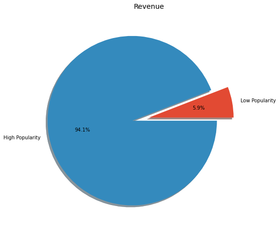

```python
# get mean revenue for the low and high popularity groups
mean_low_pop = low_pop.revenue.mean()
mean_high_pop = high_pop.revenue.mean()
pie_fig = plt.figure(figsize=(8,8))
plt.pie(
    [mean_low_pop, mean_high_pop], labels=["Low Popularity", "High Popularity"],
    autopct='%2.1f%%', explode=[0,0.2], shadow=True)
plt.title("Revenue");
```

> From the chart above, we can see that movies with high popularity generate more revenue than those with low popularity.

#### 2.) Do movies with high budget have high revenues?

```python
# Let's get the mean of the budget
median_bud = df.budget.median()
median_bud
```

```
200000.0
```

```python
# select samples with budget less than the median
low_budget = df.query(f"budget < {median_bud}")

# select samples with budget greater than or equal to the median
high_budget = df.query(f"budget >= {median_bud}")

# ensure these queries included each sample exactly once
num_samples = df.shape[0]
num_samples == low_budget.revenue.count() + high_budget.revenue.count() # should be True
```

```
True
```

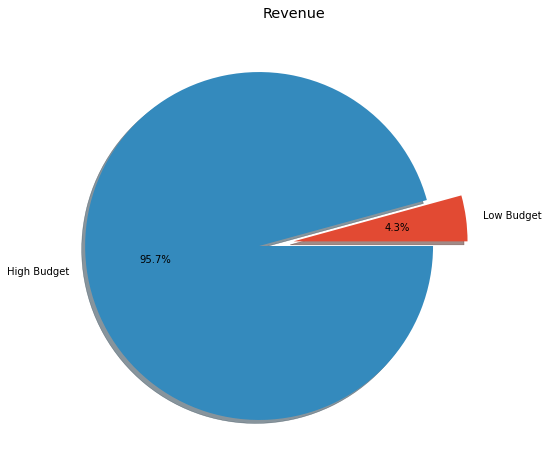

```python
# get mean revenue for the low and high popularity groups
mean_low_budget = low_budget.revenue.mean()
mean_high_budget = high_budget.revenue.mean()
pie_fig = plt.figure(figsize=(8,8))
plt.pie(
    [mean_low_budget, mean_high_budget], labels=["Low Budget", "High Budget"],
    autopct='%2.1f%%', explode=[0,0.2], shadow=True)
plt.title("Revenue");
```

> The chart shows that majority of the movies which were made with a high budget, generate more revenue in return than those with lower budget.

#### 3.) Do movies with high vote_average have high revenues?

```python
# First, let's get the median of the vote_average
median_vt = df.vote_average.median()
median_vt
```

```
6.0
```

```python
# select samples with vote_average less than the median
low_vt = df.query(f"vote_average < {median_vt}")

# select samples with vote_average greater than or equal to the median
high_vt = df.query(f"vote_average >= {median_vt}")

# ensure these queries included each sample exactly once
num_samples = df.shape[0]
num_samples == low_vt.revenue.count() + high_vt.revenue.count() # should be True
```

```
True
```

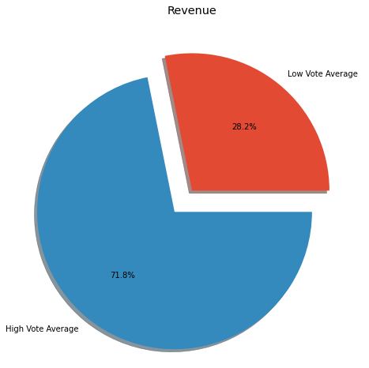

```python
# get mean revenue for the low and high voting_average groups
mean_low_vt = low_vt.revenue.mean()
mean_high_vt = high_vt.revenue.mean()
pie_fig = plt.figure(figsize=(8,8))
plt.pie(
    [mean_low_vt, mean_high_vt], labels=["Low Vote Average", "High Vote Average"],
    autopct='%2.1f%%', explode=[0,0.2], shadow=True)
plt.title("Revenue");
```

> The chart shows that movies that got higher vote average, made higher revenue

### Research Question 3 (Are movies with high revenue synonymous with high votes?)

> Fortunately, we have already answered this question in the cell above in the third question in **Research Question 2** where we asked about the relationship between high vote average and high revenue.

> Refer to Relationship Between High Vote Average and High Revenue to view solution.

### Research Question 4 (Which directors directed the most popular movie each year?)

> Here, we are going to find out which directors who directed the mosted popular movie in every year. To achieve that, we are going to take the following steps:
> - Group the data by `year` and select the `max()`
> - Select the `popularity` and `director` columns.
> - Display a list of the directors

> We have grouped by year earlier and stored the result in the variable `year_grouped`, so we just refrence that variable and select the required columns

```python
pop_directors = year_grouped.loc[:, ["popularity", "director"]]
pop_directors
```

| release_year | popularity | director |
| --- | --- | --- |
| 1960 | 2.610362 | Wolf Rilla |
| 1961 | 2.631987 | Yuri Chulyukin |
| 1962 | 3.170651 | Vittorio De Sica\|Federico Fellini\|Luchino Visc... |
| 1963 | 2.508235 | Wolfgang Reitherman |
| 1964 | 3.153791 | Ubaldo Ragona\|Sidney Salkow |
| 1965 | 1.910465 | William Castle |
| 1966 | 1.227582 | Woody Allen |
| 1967 | 2.550704 | Wolfgang Reitherman |
| 1968 | 3.309196 | William Wyler |
| 1969 | 1.778746 | Woody Allen |
| 1970 | 1.936962 | Wolfgang Reitherman |
| 1971 | 3.072555 | Woody Allen |
| 1972 | 5.738034 | Woody Allen |
| 1973 | 2.272486 | Woody Allen |
| 1974 | 3.264571 | Tobe Hooper |
| 1975 | 3.258151 | Woody Allen |
| 1976 | 2.582657 | Sidney Lumet |
| 1977 | 12.037933 | Woody Allen |
| 1978 | 1.697618 | William Girdler |
| 1979 | 4.935897 | Woody Allen |
| 1980 | 5.488441 | Woody Allen |
| 1981 | 4.578300 | Warren Beatty |
| 1982 | 4.215642 | Woody Allen |
| 1983 | 4.828854 | Woody Allen |
| 1984 | 4.831966 | Woody Allen |
| 1985 | 6.095293 | Woody Allen |
| 1986 | 2.485419 | Woody Allen |
| 1987 | 3.474728 | Y.K. Kim\|Woo-sang Park |
| 1988 | 3.777441 | Étienne Chatiliez |
| 1989 | 4.143585 | Zalman King |
| 1990 | 2.679627 | Woody Allen |
| 1991 | 3.852269 | Woody Allen |
| 1992 | 4.586426 | Woody Allen |
| 1993 | 2.571339 | Ãlex de la Iglesia |
| 1994 | 8.093754 | Yuen Woo-Ping |
| 1995 | 4.765359 | Étienne Chatiliez |
| 1996 | 4.480733 | Woody Allen |
| 1997 | 4.355219 | Woody Allen |
| 1998 | 4.180540 | Woody Allen |
| 1999 | 8.947905 | Woody Allen |
| 2000 | 4.271452 | Yves Simoneau |
| 2001 | 8.575419 | Étienne Chatiliez |
| 2002 | 8.095275 | Wych Kaosayananda |
| 2003 | 7.122455 | Émile Gaudreault |
| 2004 | 5.827781 | Zack Snyder |
| 2005 | 5.939927 | ÇaÄŸan Irmak |
| 2006 | 5.838503 | Yasuhiro Yoshiura |
| 2007 | 4.965391 | Zoe R. Cassavetes |
| 2008 | 8.466668 | Özgür Yildirim |
| 2009 | 9.432768 | Àlex Pastor\|David Pastor |
| 2010 | 9.363643 | Éric Besnard |
| 2011 | 7.959228 | Zal Batmanglij |
| 2012 | 7.637767 | Ziad Doueiri |
| 2013 | 6.112766 | Zalman King |
| 2014 | 24.949134 | Ãdám Császi |
| 2015 | 32.985763 | Zeke Norton |

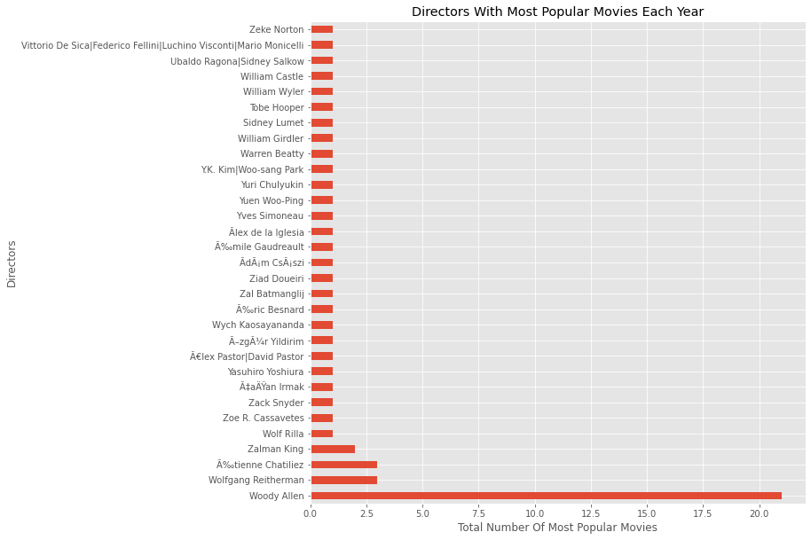

```python
pop_directors["director"].value_counts()\
                         .plot(kind="barh", figsize=(10,10));
plt.title("Directors With Most Popular Movies Each Year");
plt.ylabel("Directors");
plt.xlabel("Total Number Of Most Popular Movies");
```

### Research Question 5 (Which year has the highest revenue?)

> Here we are going to find the year the highest revenue was made from a movie. To do this, we are going to:
> - Get the maximum revenue from the `revenue` column
> - Get the year where the maximum revenue occured

```python
max_revenue = df.revenue.max()
max_revenue
```

```
2781505847
```

```python
year_ans = df.query(f"revenue == {max_revenue}")
year_ans
```

|  | id | popularity | budget | revenue | original_title | cast | director | runtime | genres | production_companies | release_date | vote_count | vote_average | release_year | budget_adj | revenue_adj |
| --- | --- | --- | --- | --- | --- | --- | --- | --- | --- | --- | --- | --- | --- | --- | --- | --- |
| 1386 | 19995 | 9.432768 | 237000000 | 2781505847 | Avatar | Sam Worthington\|Zoe Saldana\|Sigourney Weaver\|S... | James Cameron | 162 | Action\|Adventure\|Fantasy\|Science Fiction | Ingenious Film Partners\|Twentieth Century Fox ... | 2009-12-10 | 8458 | 7.1 | 2009 | 2.408869e+08 | 2.827124e+09 |

```python
display("The year with the highest revenue is: ", year_ans.release_year)
```

```
'The year with the highest revenue is: '
```

```
1386    2009
Name: release_year, dtype: int64
```

### Research Question 6 (Which director has directed the most movies?)

> Here we are simply going to find the director with the highest number of movies. To do this, we are going to get the count of the `value_counts()` of the directors

```python
df.director.value_counts()
```

```
Woody Allen                         42
Clint Eastwood                      34
Steven Spielberg                    29
Martin Scorsese                     26
Ridley Scott                        23
                                    ..
Alberto Sironi                       1
Brett Simon                          1
Mike Maguire|Tom Kuntz               1
Susanna White|Simon Cellan Jones     1
Harold P. Warren                     1
Name: director, Length: 4505, dtype: int64
```

> From the cell above we can see that the director with the most movies is **Woody Allen**

## Conclusions

### Limitations

> I found the feature `vote_average` a bit misleading. This is because (assuming that it is the mean value of the vote counts) movies with have very few value of `vote_count` turn out to have a relative high value of `vote_average` due to the way it is computed. It now begs the questions: Is comparing the `vote_average` of such movies with those that have a very high value of `vote_count` but a relatively average or slightly above average value of `vote_average` a good comparism?, Is there a better way to compute this feature?

> Some columns with `NaN` values such as `production_companies`, `genres` and `director` did not leave much options on how to handle them than to drop the null rows because they are categorical features so filling them with measures of dispersion such as `mean()`, or `median()` might not make much of valid sense.

> I did not find the feature `cast` to be of any use. However, I strongly believe that if there was a derive of the feature which translates to **Lead Role**, it might be of relevance in the data.